# Developing Data Products Course Project

2022-04-29

## Introduction

swiss_app is an app created in shiny to plot the swiss dataset, which is a dataset of the datasets package. It consists of standarized fertility measure and socioeconomic indicators for each of 47 French-speaking provinces of Switzerland at about 1888.

## Format

A dataframe with 47 observations on 6 variables, each of which is in percent.

- Fertility, Ig, ’common standardized fertility measure
- Agriculture, % of males involved in agriculture as occupation
- Examination % draftees receiving highest mark on army examination
- Education, % education beyond primary school for draftees.
- Catholic, % ‘catholic’ (as opposed to ‘protestant’).
- Infant.Mortality, live births who live less than 1 year.

## Shiny app

The app shows a dropdown list of variables in the left panel. Both x an y values can be selected for plotting and also a method for the regression model can be selected. Linear regression, robust linear model and quantile regression are suported.

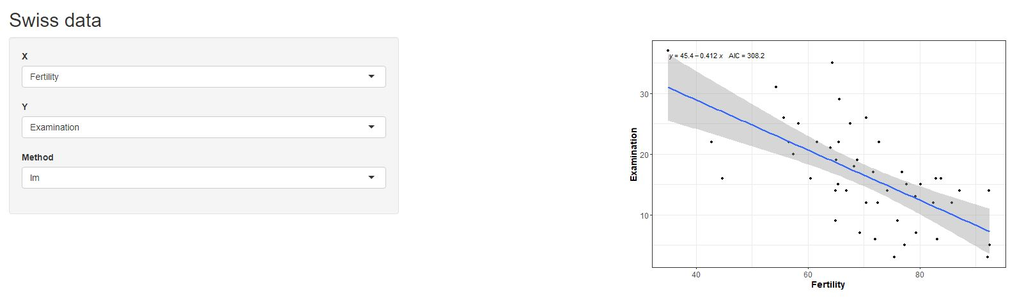

Variables

## Plot

The resulting plot shows the equation and the Aikake Information Criterion (AIC) for each model.

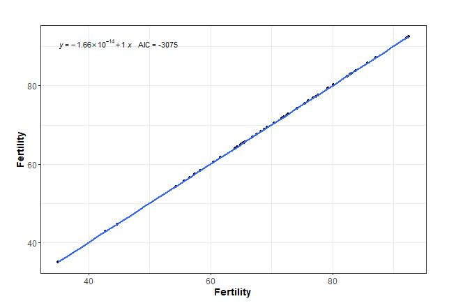